# liga1

[figure not shown]

[figure not shown]

**LIGAÇÃO I**

Prof. Saulo Chaves

ESALQ / USP - Departamento de Genética

LGN 215 - Genética

## Anteriormente em LGN0215

**Princípio da segregação**

*Cada organismo diploide individual tem dois alelos para uma característica em particular, um herdado do genitor materno e outro do genitor paterno. Esses dois alelos se segregam durante a formação dos gametas e cada um vai para um gameta. Além disso, os dois alelos se separam nos gametas em proporções iguais*

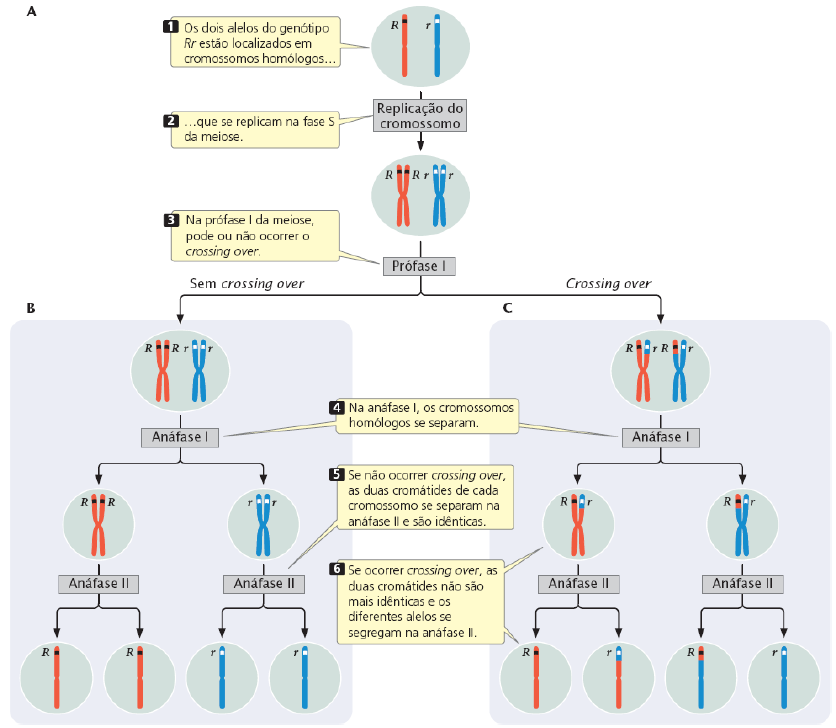

Pierce (2016)

## Anteriormente em LGN0215

**Princípio da dominância**

*Quando existem dois alelos diferentes em um genótipo, apenas a característica manifestada codificado por um deles – o alelo “dominante” – é observada no fenótipo*

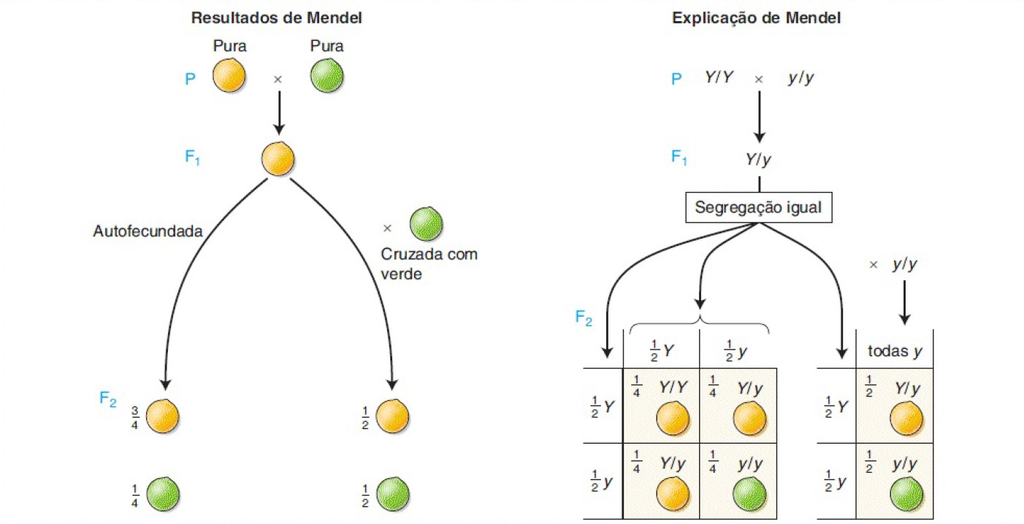

Griffiths et al. (2013)

## Anteriormente em LGN0215

**Princípio da segregação independente**

*Diferentes pares de genes se distribuem independentemente durante a formação dos gametas. Isto ocorre quando pares de locos em cromossomos diferentes se distribuem independentemente na meiose*

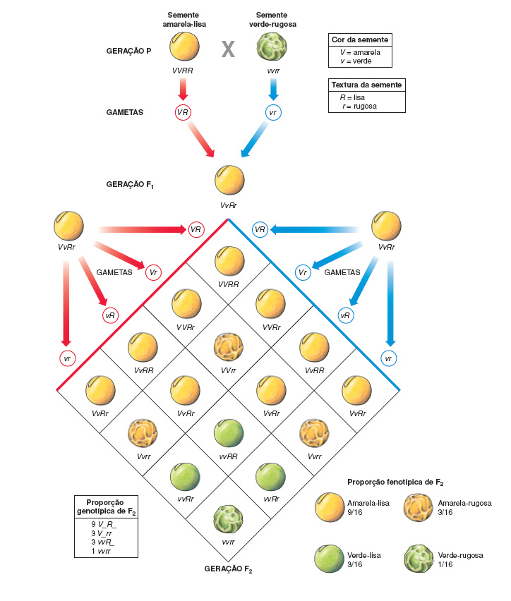

[Planejativo](https://app.planejativo.com/estudar/385/resumo/biologia-segunda-lei-de-mendel)

## Conteúdo de hoje

1. A genética dos genes ligados
   - Recombinação entre cromátides não-irmãs
   - Cruzamento-teste de dois pontos
   - Genes ligados e o *crossing-over*
2. Mapas de ligação
   - Frequência de recombinação
   - Linearidade dos mapas
   - Predição da proporção genotípica da progênie

# A genética dos genes ligados

## Recombinação intercromossômica

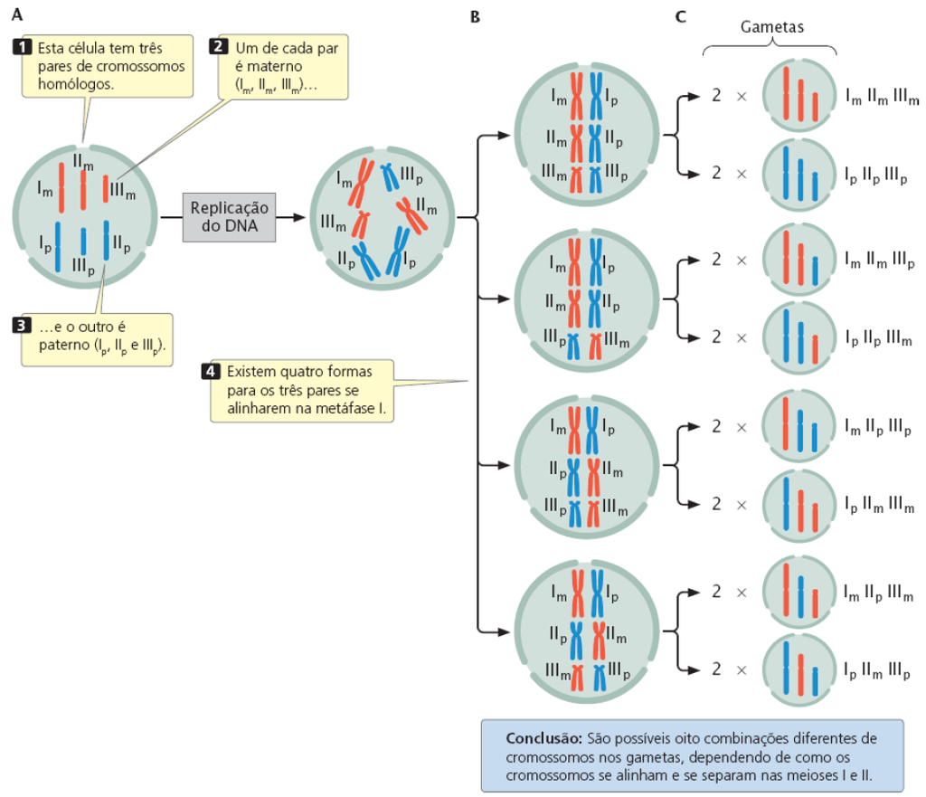

Pierce (2016)

## Recombinação intercromossômica

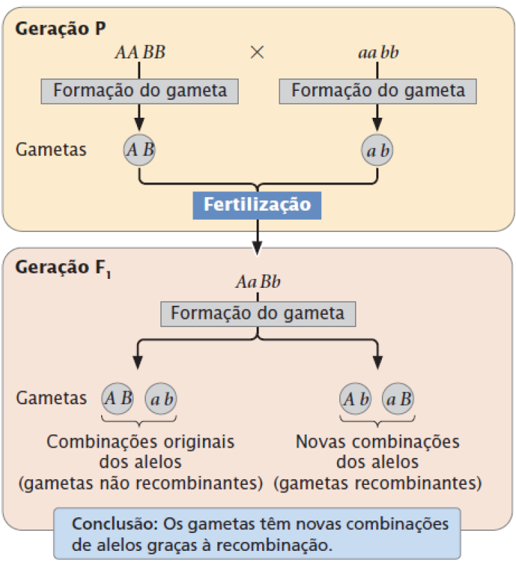

Pierce (2016)

## Recombinação intercromossômica

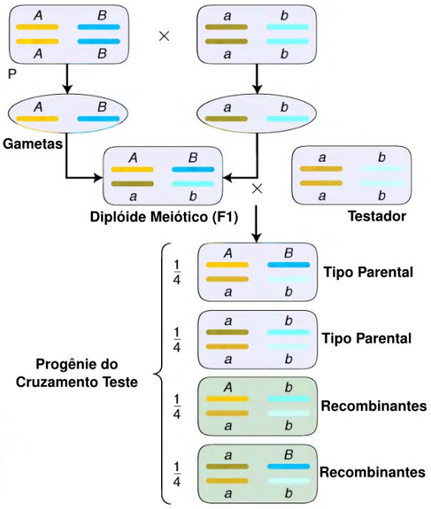

Augusto Garcia

## Recombinação

- Teoria cromossômica da herança: os genes estão localizados nos cromossomos
- Nº genes >>> Nº cromossomos
- **O que ocorre com a recombinação quando os genes encontram-se no mesmo cromossomo?**
- Nem todos os locos gênicos são independentes
  - Genes ligados $\rightarrow$ relação de dependência
- Genes no mesmo cromossomo não implicará em dependência
  - Depende da distância entre eles no cromossomo

## Experimentos de Bateson e Punnet

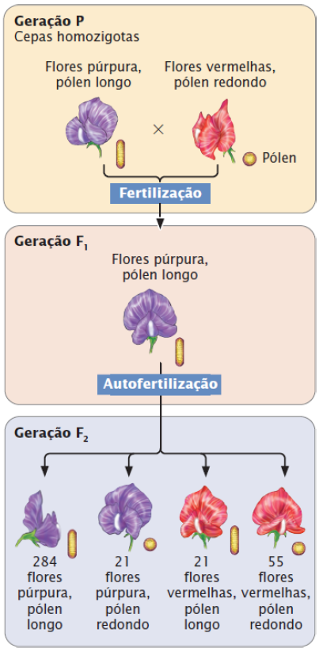

Pierce (2016)

- Quais as combinações fenotípicas parentais e recombinates?
  - Parentais: púrpura + longo e vermelha + redondo
  - Recombinantes: púrpura + redondo e vermelha + longo
- Qual a proporção esperada?
  - $9:3:3:1$
- A população segue a proporção esperada?

## Experimentos de Bateson e Punnet

| Fenótipo | Tipo | Observado | Esperado |
| --- | --- | --- | --- |
| Púrpura e longo | Parental | 284 | 214 |
| Púrpura e redondo | Recombinante | 21 | 71 |
| Vermelha e longo | Recombinante | 21 | 71 |
| Vermelha e redondo | Parental | 55 | 24 |

$$\chi^2 = \frac{(284-214)^2}{214} + \frac{(21-71)^2}{71} + \frac{(21-71)^2}{71} + \frac{(55-24)^2}{24} = 134,73$$

Decisão?

## Thomas Morgan (de novo)

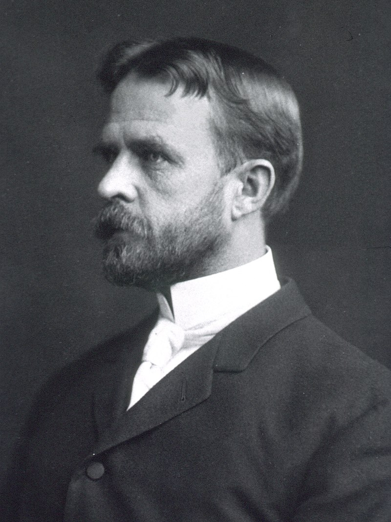

[Wiki](https://pt.wikipedia.org/wiki/Thomas_Hunt_Morgan)

[figure not shown]

[Christina Koci](https://br.pinterest.com/pin/reminds-me-of-my-1st-genetics-class-oh-drosophila-flies-how-i-dislike-you--104990235039481734/)

## Thomas Morgan (de novo)

- Olhos: **A** $\rightarrow$ vermelhos; **a** $\rightarrow$ roxos
- Asas: **B** $\rightarrow$ normais; **b** $\rightarrow$ vestigiais

[figure not shown]

## Thomas Morgan (de novo)

Cruzamento-teste:

[figure not shown]

## Thomas Morgan (de novo)

| Genótipo | Tipo | Observado | Esperado |
| --- | --- | --- | --- |
| AABB | Parental | 1339 | 710 |
| Aabb | Recombinante | 151 | 710 |
| aaBb | Recombinante | 154 | 710 |
| aabb | Parental | 1195 | 710 |

**Os genes estão ligados!**

- Os genótipos parentais aparecem com maior frequência que os recombinantes
  - Fuga da proporção mendeliana esperada (1:1:1:1)
- Explicação mais plausível: os alelos destes genes estão no mesmo cromossomo e são herdados em conjunto

## Genes ligados

Segundo cruzamento-teste:

[figure not shown]

## Genes ligados

| Genótipo | Tipo | Observado | Esperado |
| --- | --- | --- | --- |
| AABB | Recombinante | 157 | 584 |
| Aabb | Parental | 965 | 584 |
| aaBb | Parental | 1.067 | 584 |
| aabb | Recombinante | 146 | 584 |

**Cruzamento-teste de dois pontos**

## Genes ligados

**Diagnóstico de ligação**

- Duas classes de parentais igualmente frequentes que totalizam $> 50\%$
- Duas classes de recombinantes igualmente frequentes que totalizam $< 50\%$
- Fase de atração (ou conformação *cis*)

[figure not shown]

- Alelos selvagens presentes no mesmo homólogo
- Fase de repulsão (ou conformação *trans*)

[figure not shown]

- Alelos selvagens presentes em homólogos diferentes

## Genes ligados e o *crossing-over*

- Genes no mesmo cromossomo, herdados em conjunto
- Processo de recombinação intercromossômica não se aplica
- O que explica a presença de genótipos recombinantes? (ligação incompleta)

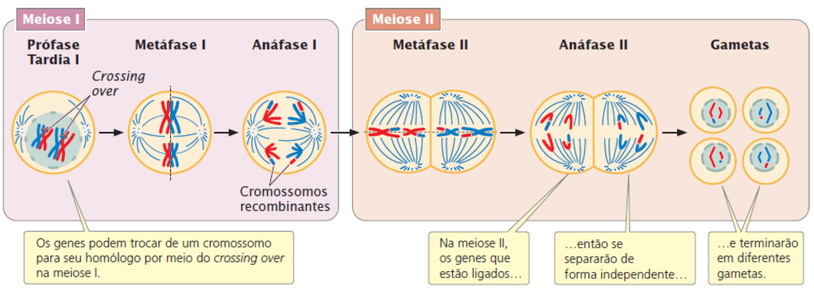

Pierce (2016)

## Genes ligados e o *crossing-over*

**Crossing-over**

Troca de segmentos cromossômicos (quebra e reparo) entre cromátides não-irmãs. A frequência máxima de recombinantes é 50% (ver abaixo).

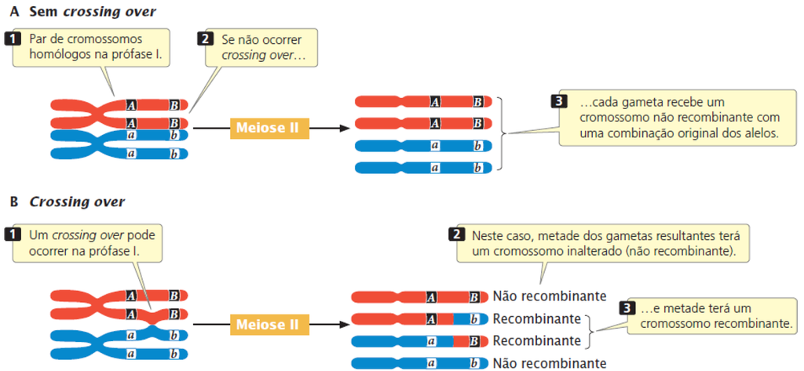

Pierce (2016)

## *Crossing-over* e recombinação

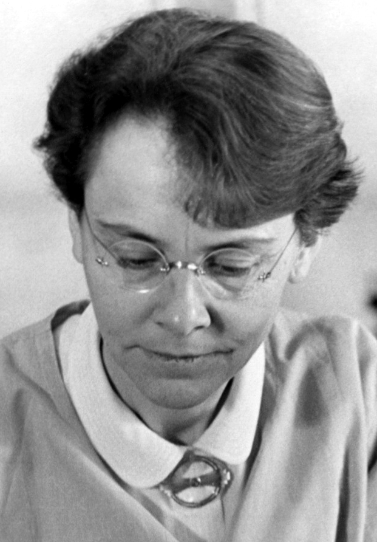

[Wiki](https://pt.wikipedia.org/wiki/Barbara_McClintock)

- Ganhadora do Prêmio Nobel de medicina
- Primeira mulher presidente da Genetics Society of America
- Terceira mulher a ser eleita para a National Academy of Sciences
- Estabeleceu provas físicas dos *crossing-overs*
  - Ligou a ocorrência dos *crossing-overs* às recombinações

## *Crossing-over* e recombinação

Evidências citológicas do crossing-over em milho

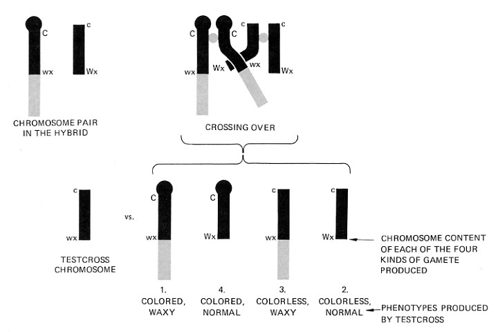

[BioLibre Texts](https://bio.libretexts.org/Bookshelves/Introductory_and_General_Biology/Biology_%28Kimball%29/08%3A_The_Genetic_Consequences_of_Meiosis/8.03%3A_The_Evidence_of_Creighton_and_McClintock)

## *Crossing-over* e recombinação

- Quiasmas: evidências citológias da recombinação
  - Cromossomos pareados permanecem em contato no centrômero e nos quiasmas
  - Nº quiasmas $\equiv$ Nº de recombinações

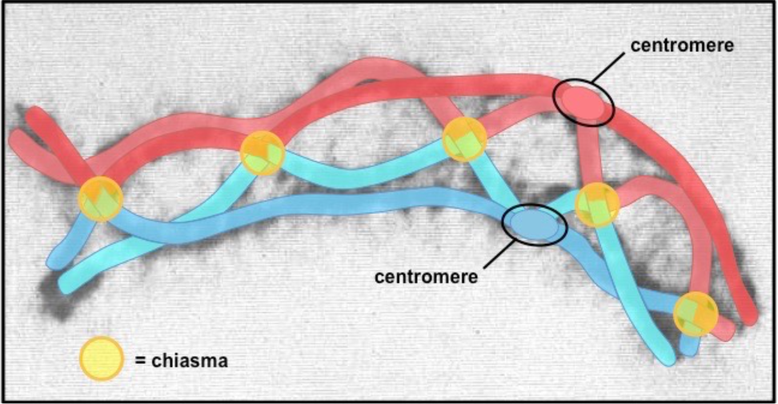

[BioNinja](https://old-ib.bioninja.com.au/higher-level/topic-10-genetics-and-evolu/101-meiosis/chiasmata.html)

# Mapas de ligação

## Frequência de recombinantes

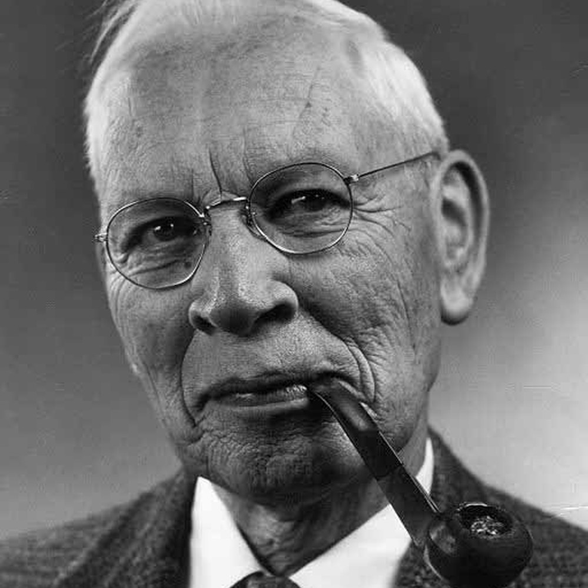

[Calisphere](https://calisphere.org/item/422d449f449e772e87f2320005625eaa/)

Alfred H. Sturtevant

- Aluno de Thomas Morgan
- Frequência de recombinantes $\leftrightarrow$ ocorrência de *crossing-overs* $\leftrightarrow$ distância entre locos
- Bases para a criação de um mapa cromossômico utilizando ligação gênica
  - Mapeamento por ligação

## Frequência de recombinantes

É mais provável que dois genes distantes um dos outros sofram um *crossing-over* que dois genes que estão próximos. Portanto, quanto mais distantes estiverem os genes, mais alta será a proporção de produtos recombinantes, até um limite máximo de 50%

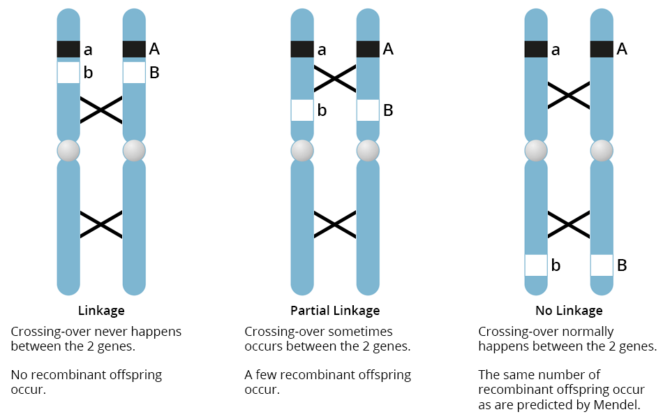

[Aldona Griskeviciene/StrongMind](https://h2.flipswitch.com/LinkPageProvider/Launch?pageIdentifier=79fd49ed-c82f-435a-96f4-c088ba21015c)

## Frequência de recombinantes

$$FR = \frac{\mbox{Nº Recombinantes}}{\mbox{Nº descendentes}} \times 100$$

| Genótipo | Tipo | Observado | Esperado |
| --- | --- | --- | --- |
| AABB | Recombinante | 157 | 584 |
| Aabb | Parental | 965 | 584 |
| aaBb | Parental | 1.067 | 584 |
| aabb | Recombinante | 146 | 584 |

$$FR = \frac{157 + 146 }{2.335} \times 100 = 13\%$$

## Mapa de ligação

**Unidade de mapa genético (u.m.)**

Distância entre genes em relação aos quais 1 produto da meiose em 100 é recombinante

$$FR = 13\% \to 13 \mbox{ u.m.}$$

- 1 u.m. $\to$ 1 cM (centiMorgan)

Primeiro mapa genético (Sturtevant):

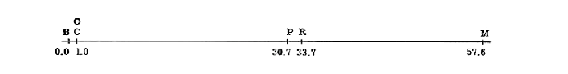

[Ana Barahona](https://calisphere.org/item/422d449f449e772e87f2320005625eaa/)

## Linearidade do mapa de ligação

[figure not shown]

[Twaanders17/Wiki](https://en.m.wikipedia.org/wiki/File:Drosophila_Gene_Linkage_Map.svg)

- Os locos estão dispostos no cromossomo de forma linear
- Distância entre os locos A e B: 13 cM
- Distância entre os locos B e C: 18 cM
- Distância entre os locos A e C: 31 cM*

## Linearidade do mapa de ligação

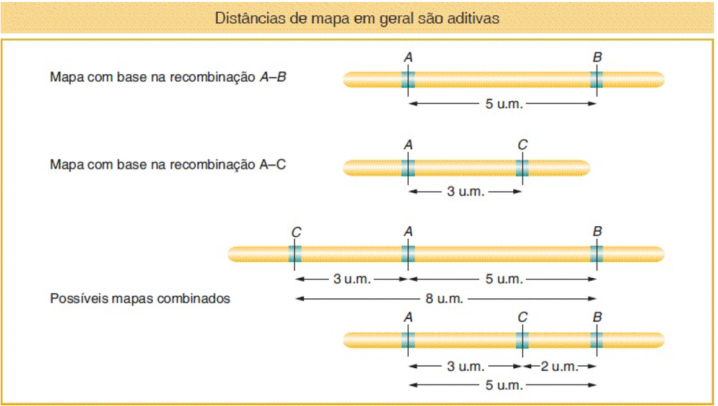

Griffiths et al. (2016)

## Mapas genéticos

*Drosophila melanogaster*

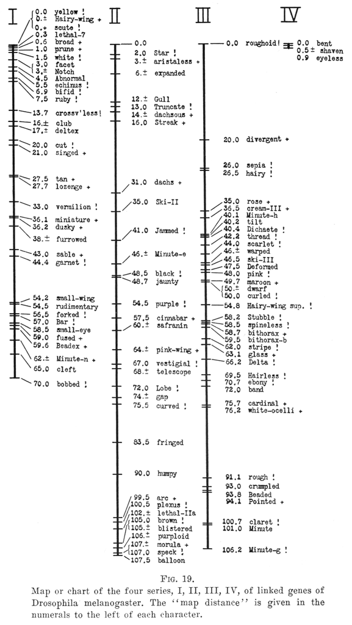

[Thomas Hunt Morgan](https://archive.org/details/theoryofgene00morg/page/22/mode/2up)

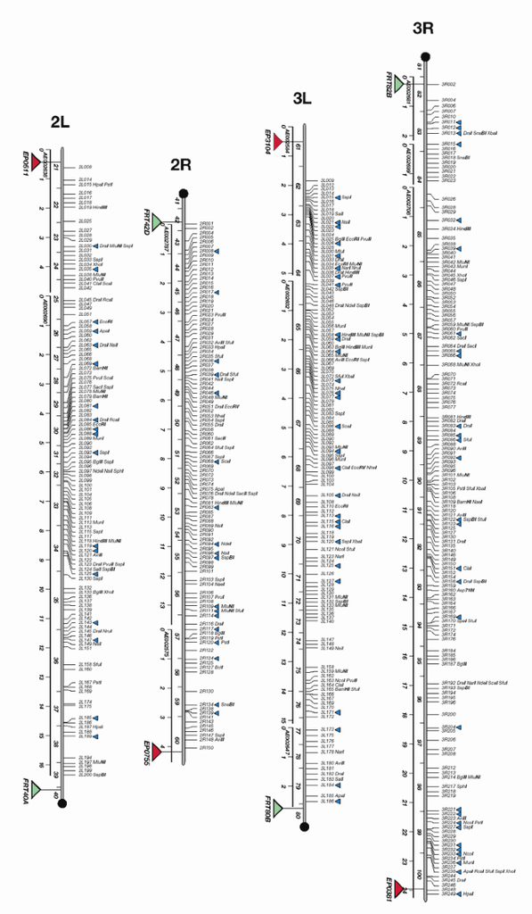

[Berger et al. (2001)](https://www.nature.com/articles/ng773)

## Mapas genéticos

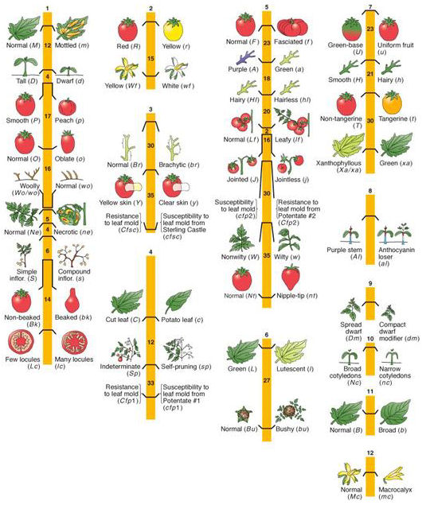

[Griffiths et al. (2002)](https://www.mun.ca/biology/scarr/MGA2-06-17c.html)

## Mapas genéticos

Ervilha: utilizando marcadores moleculares

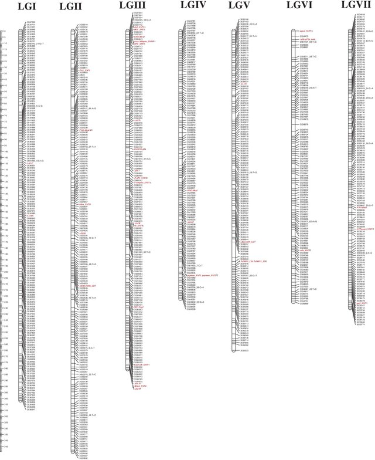

[Yuan et al. (2022)](https://www.frontiersin.org/journals/plant-science/articles/10.3389/fpls.2022.968618/full)

## Proporção genotípica na progênie

[figure not shown]

$$TD/td \times td/td$$

Quais os possíveis gametas?

Qual a proporção esperada?

## Proporção genotípica na progênie

- Gametas recombinantes: **Td** e **tD**
  - Frequência de recombinação: 16%
  - $\Pr\left(\mbox{Td}\right) = \frac{16}{2} = 8\%$
  - $\Pr\left(\mbox{tD}\right) = \frac{16}{2} = 8\%$
- Gametas não-recombinantes: $TD$ e $td$
  - $\Pr\left(\mbox{TD}\right) = \frac{84}{2} = 42\%$
  - $\Pr\left(\mbox{td}\right) = \frac{84}{2} = 42\%$

## Observações importantes

# Apanhado geral

## Vimos hoje

Genes ligados encontram-se próximos no mesmo cromossomo, e sua segregação não é independente

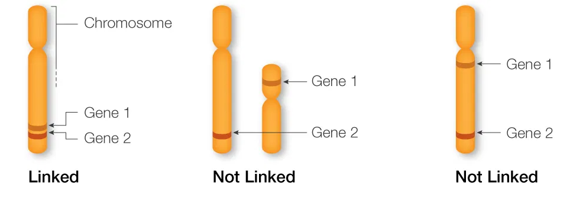

[University of Utah](https://learn.genetics.utah.edu/content/pigeons/geneticlinkage/)

## Vimos hoje

A ocorrência de gametas recombinantes se dá pela ocorrência de *crossing-overs* entre genes parcialmente ligados

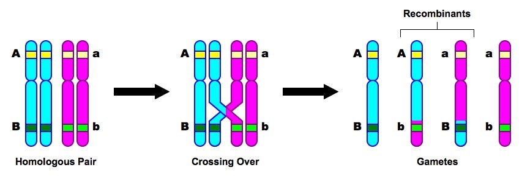

[BioNinja](https://ib.bioninja.com.au/higher-level/topic-10-genetics/102-dihybrid-crosses-and.html)

## Vimos hoje

Quanto maior a ocorrência de *crossing-overs*, maior a frequência de recombinantes. Por isso, tal frequência é um indicador de distância entre genes utilizado para a construção de mapas de ligação

[figure not shown]

[Twaanders17/Wiki](https://en.m.wikipedia.org/wiki/File:Drosophila_Gene_Linkage_Map.svg)

## Nosso LGN

Prof. Almiro Blumenschein

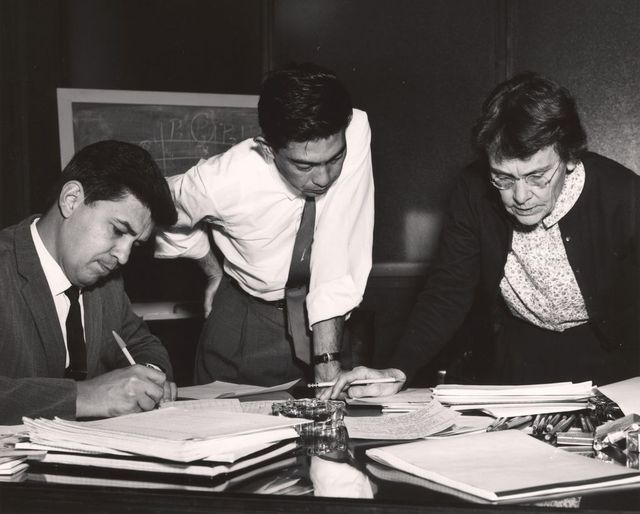

[U.S. National Library of Medicine - Profiles in Science.](https://www.genetica.esalq.usp.br/linha-do-tempo)

## Para fixação

1. **Faça um esquema representando os dois fenômenos que produzem gametas recombinantes. Nesse esquema, ressalte as condições para que dois locos sejam considerados ligados e explique como a ocorrência destes locos afeta a ocorrência de recombinantes.**
2. No que implica dois locos estarem organizados em repulsão ou atração?
3. A cor do aquênio em alface é controlada por um gene com dominância do alelo que condiciona aquênio preto (**W**) sobre o branco (**w**). Por seu turno, a ocorrência de folhas com os bordos ondulados é condicionada por um alelo recessivo (**fr**) e o alelo dominante condiciona folha lisa (**Fr**). Considerando que esses dois genes estão situados no mesmo cromossomo a 34 cM, qual a proporção fenotípica esperada na geração F2 do seguinte cruzamento entre um genitor com aquênios pretos e folhas onduladas e outro de aquênios brancos e folhas lisas? Se o cruzamento-teste fosse realizado, qual a proporção esperada?
4. No caupi, o alelo **I**, dominante, é responsável pela resistência ao vírus da mancha anelar e está ligado ao alelo **C**, também dominante, que confere resistência ao vírus do mosaico. O cruzamento de uma planta resistente às duas doenças com outra suscetível produziu a seguinte descendência:
   - 440 plantas resistentes aos dois vírus;
   - ? plantas suscetíveis aos dois vírus;
   - ? plantas resistentes apenas ao vírus da mancha anelar;
   - 145 plantas resistentes apenas ao vírus do mosaico.
   1. Qual a distância entre os genes? Qual seria a distância entre os genes e o número esperado de cada classe fenotípica se os locos fossem independentes?
   2. Indique os genótipos dos genitores e dos descendentes do cruzamento.
   3. Qual a fase de ligação dos genes, no genitor resistente?

## Material de apoio

- GRIFFITHS, A. J. F., WESSLER, S. R., CARROLL, S. B., & DOEBLEY, J. (2016). Capítulo 4: Mapeamento de cromossomos eucarióticos por recombinação. Introdução à Genética.
- RAMALHO, M. A. P., SANTOS, J. B., & PINTO, C. A. B. P. (2004). Capítulo 9: Ligação, permuta genética e pleiotropia. Genética Na Agropecuária.
- SNUSTAD, D. P., & SIMMONS, M. J. (2010). Capítulo 7: Ligação, crossing-over e mapeamento cromossômico em eucariotos. Fundamentos de Genética.
- [Sobre Barbara McClintock](https://www.youtube.com/watch?v=LrY78SwZ3II&ab_channel=NationalLibraryofMedicine)
- [O experimento de Sturtevant](https://www.youtube.com/watch?v=VCCHiFgjf9M)
- [Mapas genéticos](https://h2.flipswitch.com/LinkPageProvider/Launch?pageIdentifier=79fd49ed-c82f-435a-96f4-c088ba21015c)